# Crack detection using CNN

Importing required library

```python
import numpy as np
import pandas as pd

import matplotlib.pyplot as plt
import seaborn as sns
import plotly.express as px

from pathlib import Path
from sklearn.model_selection import train_test_split

import tensorflow as tf
from tensorflow import keras
from tensorflow.keras import layers

from sklearn.metrics import confusion_matrix, classification_report

from keras.models import model_from_json
```

# Two classes

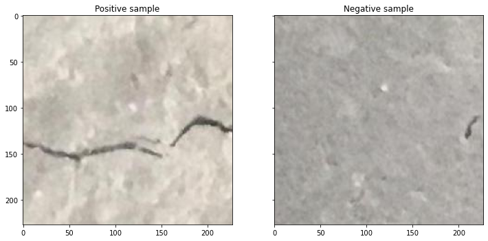

```python
pos_sample = plt.imread('C:/Users/Asus/Downloads/Concrete Crack Images for Classification/Positive/00040.jpg')
neg_sample = plt.imread('C:/Users/Asus/Downloads/Concrete Crack Images for Classification/Negative/00001.jpg')
plt.figure()
fig, ax = plt.subplots(1,2, figsize=(12,12), sharey=True)
ax[0].imshow(pos_sample)
ax[0].set_title("Positive sample")
ax[1].imshow(neg_sample)
ax[1].set_title("Negative sample")

plt.show()
```

```python
pip install opencv-python
```

# I try to show how a crack could be detected. We first take the Threshold of the image and then define the edges. We then find the contours of the crack and fit it to the original image.

```
Visualizing Sample Image in Threshold, Canny & Contours
=====================================================
```

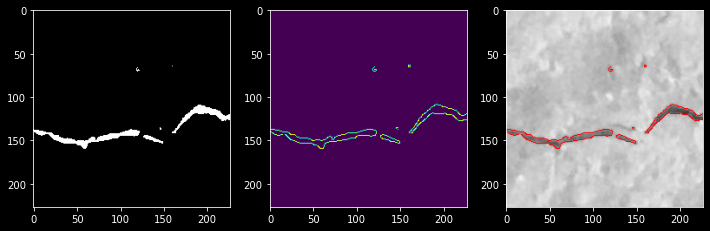

```python
import cv2

plt.style.use("dark_background")
figure,axis = plt.subplots(nrows=1,ncols=3,figsize=(12,12))

Reading_Img = cv2.imread("C:/Users/Asus/Downloads/Concrete Crack Images for Classification/Positive/00040.jpg", cv2.IMREAD_GRAYSCALE)
Reading_Img = cv2.cvtColor(Reading_Img,cv2.COLOR_BGR2RGB)

_,Threshold_Img = cv2.threshold(Reading_Img,150,255,cv2.THRESH_BINARY_INV)
Canny_Img = cv2.Canny(Threshold_Img,90,100)
contours,_ = cv2.findContours(Canny_Img,cv2.RETR_EXTERNAL,cv2.CHAIN_APPROX_SIMPLE)
Draw_Contours = cv2.drawContours(Reading_Img,contours,-1,(255,0,0),1)

axis[0].imshow(Threshold_Img)
axis[1].imshow(Canny_Img)
axis[2].imshow(Draw_Contours)

print("Visualizing Sample Image in Threshold, Canny & Contours\n=====================================================\n")
```

```python
pos_dir = Path('C:/Users/Asus/Downloads/Concrete Crack Images for Classification/Positive')
neg_dir = Path('C:/Users/Asus/Downloads/Concrete Crack Images for Classification/Negative')
```

# Creating Data Frames

```python
def generate_df(image_dir, label):
    filepaths = pd.Series(list(image_dir.glob(r'*.jpg')), name='Filepath').astype(str)
    labels = pd.Series(label, name='Label', index=filepaths.index)
    df = pd.concat([filepaths, labels], axis=1)
    return df
```

We assign a label to each image

```python
pos_df = generate_df(pos_dir, "POSITIVE")
neg_df = generate_df(neg_dir, "NEGATIVE")

all_df = pd.concat([pos_df, neg_df], axis=0).sample(frac=1.0, random_state=1).reset_index(drop=True) #shuffle the data, random_state for reproducibility
all_df
```

|  | Filepath | Label |
| --- | --- | --- |
| 0 | C:\Users\Asus\Downloads\Concrete Crack Images ... | POSITIVE |
| 1 | C:\Users\Asus\Downloads\Concrete Crack Images ... | POSITIVE |
| 2 | C:\Users\Asus\Downloads\Concrete Crack Images ... | POSITIVE |
| 3 | C:\Users\Asus\Downloads\Concrete Crack Images ... | NEGATIVE |
| 4 | C:\Users\Asus\Downloads\Concrete Crack Images ... | POSITIVE |
| ... | ... | ... |
| 39995 | C:\Users\Asus\Downloads\Concrete Crack Images ... | POSITIVE |
| 39996 | C:\Users\Asus\Downloads\Concrete Crack Images ... | NEGATIVE |
| 39997 | C:\Users\Asus\Downloads\Concrete Crack Images ... | POSITIVE |
| 39998 | C:\Users\Asus\Downloads\Concrete Crack Images ... | POSITIVE |
| 39999 | C:\Users\Asus\Downloads\Concrete Crack Images ... | NEGATIVE |

40000 rows × 2 columns

Separation of data set into train and test set

```python
train_df, test_df = train_test_split(
    all_df.sample(6000, random_state=1), #since there is 40000 images in total, we sample only 6000 for speed up the training
    train_size = 0.7, #train set is 70% and the rest is the test set
    shuffle=True,
    random_state=1
)
```

Loading the data

ImageDataGenerator for better performance. This department is responsible for loading the images and then teaching them.

```python
train_gen = tf.keras.preprocessing.image.ImageDataGenerator(
    rescale=1./255, #pixel values down into a range of between 0 and 1
    validation_split=0.2
)

test_gen = tf.keras.preprocessing.image.ImageDataGenerator(
    rescale=1./255
)
```

```python
train_data = train_gen.flow_from_dataframe(
    train_df, #load from train set
    x_col='Filepath',
    y_col='Label',
    target_size=(128,128), #image size
    color_mode='rgb',
    class_mode='binary', #binary classification
    batch_size=32,
    shuffle=True,
    seed=42,
    subset='training'
)

val_data = train_gen.flow_from_dataframe(
    train_df,
    x_col='Filepath',
    y_col='Label',
    target_size=(128,128),
    color_mode='rgb',
    class_mode='binary',
    batch_size=32,
    shuffle=True,
    seed=42,
    subset='validation'
)

test_data = test_gen.flow_from_dataframe(
    test_df,
    x_col='Filepath',
    y_col='Label',
    target_size=(128,128),
    color_mode='rgb',
    class_mode='binary',
    batch_size=32,
    shuffle=False,
    seed=42,
)
```

```
Found 3360 validated image filenames belonging to 2 classes.
Found 840 validated image filenames belonging to 2 classes.
Found 1800 validated image filenames belonging to 2 classes.
```

Creating models

It will be true for all models that there will always be a Dense neuron in its header whose activation function is sigmoid. So we get a number between 0 and 1. If the estimate is below 0.5 then the sample is negative (no crack), otherwise it is.

```python
basic_model = tf.keras.Sequential([
    layers.InputLayer(input_shape=[128,128,3]),

    layers.Conv2D(filters=16, kernel_size=3, activation='relu', padding='same'),
    layers.MaxPool2D(),

    layers.Flatten(),
    layers.Dense(1, activation='sigmoid')
], name='basic_model')
```

```python
wider_model = tf.keras.Sequential([
    layers.InputLayer(input_shape=[128,128,3]),

    layers.Conv2D(filters=16, kernel_size=(3,3), activation='relu', padding='same'),
    layers.MaxPool2D(pool_size=(2,2)),

    layers.Conv2D(filters=32, kernel_size=(3,3), activation='relu', padding='same'),
    layers.MaxPool2D(pool_size=(2,2)),

    layers.Flatten(),
    layers.Dense(1, activation='sigmoid')
], name='wider_model')
```

Deeper model

```python
deeper_model = tf.keras.Sequential([
    layers.InputLayer(input_shape=[128,128,3]),

    layers.Conv2D(filters=16, kernel_size=(3,3), activation='relu', padding='same'),
    layers.MaxPool2D(),

    layers.Conv2D(filters=32, kernel_size=(3,3), activation='relu', padding='same'),
    layers.MaxPool2D(),

    layers.Conv2D(filters=64, kernel_size=(3,3), activation='relu', padding='same'),
    layers.MaxPool2D(),

    layers.Flatten(),
    layers.Dense(1, activation='sigmoid')
], name='deeper_model')
```

In this model, we try the GlobalAveragePooling2D layer

```python
global_avg_model = tf.keras.Sequential([
    layers.InputLayer(input_shape=[128,128,3]),

    layers.Conv2D(filters=8, kernel_size=(3,3), activation='relu', padding='same'),
    layers.MaxPool2D(),

    layers.Conv2D(filters=16, kernel_size=(3,3), activation='relu', padding='same'),
    layers.MaxPool2D(),

    layers.GlobalAveragePooling2D(),
    layers.Dense(1, activation='sigmoid')
], name='global_avg_model')
```

Here we placed a Dropout layer between the two Dense layers in the header. All it does is break the connection between individual neurons with a 20% chance, encouraging the mesh to change its weights differently. This layer is extremely useful against overfitting due to its ability to generalize.

```python
dropout_model = tf.keras.Sequential([
    layers.InputLayer(input_shape=[128,128,3]),

    layers.Conv2D(filters=16, kernel_size=(3,3), activation='relu', padding='same'),
    layers.MaxPool2D(),

    layers.Conv2D(filters=32, kernel_size=(3,3), activation='relu', padding='same'),
    layers.MaxPool2D(),

    layers.Flatten(),
    layers.Dense(4, activation='relu'),
    layers.Dropout(0.2),
    layers.Dense(1, activation='sigmoid')
], name='dropout_model')
```

In this model, the BatchNormalization layer was tested. The benefit is that each feature map will have the same standard distribution.

```python
batch_normal_model = tf.keras.Sequential([
    layers.InputLayer(input_shape=[128,128,3]),

    layers.Conv2D(filters=8, kernel_size=(3,3), activation='relu', padding='same'),
    layers.BatchNormalization(),
    layers.MaxPool2D(),

    layers.Conv2D(filters=16, kernel_size=(3,3), activation='relu', padding='same'),
    layers.BatchNormalization(),
    layers.MaxPool2D(),

    layers.Flatten(),
    layers.Dense(1, activation='sigmoid')
], name='batch_normal_model')
```

```python
def compile_model(model, optimizer='adam'):
    model.compile(
        optimizer=optimizer, #adam optimizer
        loss='binary_crossentropy', #loss function
        metrics=['binary_accuracy']
    )
    model.summary()

def fit_model(model, train_data, val_data):
    history = model.fit(
        train_data,
        validation_data=val_data,
        epochs=100,
        callbacks=[
            tf.keras.callbacks.EarlyStopping( #early stopping to preventing overfit
                monitor='val_loss',
                patience=3,
                restore_best_weights=True #if the validation loss is increasing for 3 epochs, stop and restore the weights
            )
        ]
    )
    return history

def plot_history(history):
    history_frame = pd.DataFrame(history.history)
    history_frame.loc[:, ['loss', 'val_loss']].plot()
    history_frame.loc[:, ['binary_accuracy', 'val_binary_accuracy']].plot();

def save_model(model):
    model_json = model.to_json()
    with open(model.name + ".json", "w") as json_file:
        json_file.write(model_json)
    model.save_weights(model.name + ".h5")
    print(model.name + " is saved")

def load_model(model):
    json_file = open(model.name + ".json", "r")
    loaded_model_json = json_file.read()
    json_file.close()
    loaded_model = model_from_json(loaded_model_json)
    loaded_model.load_weights(model.name + ".h5")
    print(model.name + " is loaded")
    return loaded_model

def train_model(model, optimizer='adam', train_data=train_data, val_data=val_data):
    compile_model(model, optimizer)
    history = fit_model(model, train_data, val_data)
    #save_model(model)
    plot_history(history)
```

# Training

```
Model: "basic_model"
_________________________________________________________________
 Layer (type)                Output Shape              Param #
=================================================================
 conv2d (Conv2D)             (None, 128, 128, 16)      448

 max_pooling2d (MaxPooling2D  (None, 64, 64, 16)       0
 )

 flatten (Flatten)           (None, 65536)             0

 dense (Dense)               (None, 1)                 65537

=================================================================
Total params: 65,985
Trainable params: 65,985
Non-trainable params: 0
_________________________________________________________________
```

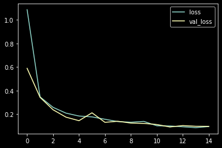

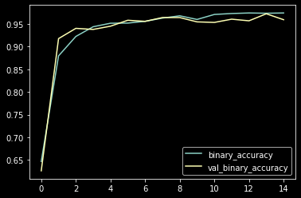

```python
train_model(basic_model)
```

```
Model: "wider_model"
_________________________________________________________________
 Layer (type)                Output Shape              Param #
=================================================================
 conv2d_1 (Conv2D)           (None, 128, 128, 16)      448

 max_pooling2d_1 (MaxPooling  (None, 64, 64, 16)       0
 2D)

 conv2d_2 (Conv2D)           (None, 64, 64, 32)        4640

 max_pooling2d_2 (MaxPooling  (None, 32, 32, 32)       0
 2D)

 flatten_1 (Flatten)         (None, 32768)             0

 dense_1 (Dense)             (None, 1)                 32769

=================================================================
Total params: 37,857
Trainable params: 37,857
Non-trainable params: 0
_________________________________________________________________
```

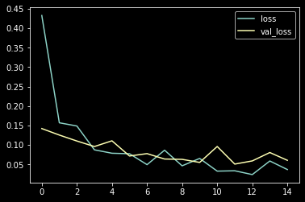

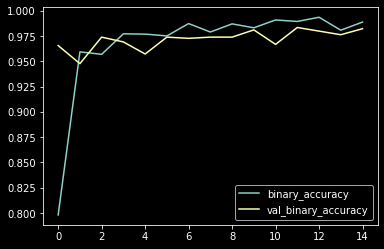

```python
 train_model(wider_model)
```

```
Model: "deeper_model"
_________________________________________________________________
 Layer (type)                Output Shape              Param #
=================================================================
 conv2d_3 (Conv2D)           (None, 128, 128, 16)      448

 max_pooling2d_3 (MaxPooling  (None, 64, 64, 16)       0
 2D)

 conv2d_4 (Conv2D)           (None, 64, 64, 32)        4640

 max_pooling2d_4 (MaxPooling  (None, 32, 32, 32)       0
 2D)

 conv2d_5 (Conv2D)           (None, 32, 32, 64)        18496

 max_pooling2d_5 (MaxPooling  (None, 16, 16, 64)       0
 2D)

 flatten_2 (Flatten)         (None, 16384)             0

 dense_2 (Dense)             (None, 1)                 16385

=================================================================
Total params: 39,969
Trainable params: 39,969
Non-trainable params: 0
_________________________________________________________________
```

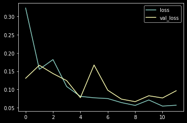

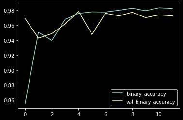

```python
train_model(deeper_model)
```

```
Model: "global_avg_model"
_________________________________________________________________
 Layer (type)                Output Shape              Param #
=================================================================
 conv2d_6 (Conv2D)           (None, 128, 128, 8)       224

 max_pooling2d_6 (MaxPooling  (None, 64, 64, 8)        0
 2D)

 conv2d_7 (Conv2D)           (None, 64, 64, 16)        1168

 max_pooling2d_7 (MaxPooling  (None, 32, 32, 16)       0
 2D)

 global_average_pooling2d (G  (None, 16)               0
 lobalAveragePooling2D)

 dense_3 (Dense)             (None, 1)                 17

=================================================================
Total params: 1,409
Trainable params: 1,409
Non-trainable params: 0
_________________________________________________________________
```

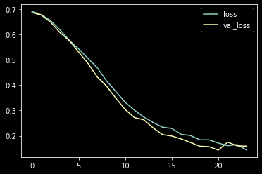

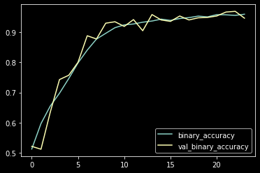

```python
train_model(global_avg_model)
```

```
Model: "batch_normal_model"
_________________________________________________________________
 Layer (type)                Output Shape              Param #
=================================================================
 conv2d_10 (Conv2D)          (None, 128, 128, 8)       224

 batch_normalization (BatchN  (None, 128, 128, 8)      32
 ormalization)

 max_pooling2d_10 (MaxPoolin  (None, 64, 64, 8)        0
 g2D)

 conv2d_11 (Conv2D)          (None, 64, 64, 16)        1168

 batch_normalization_1 (Batc  (None, 64, 64, 16)       64
 hNormalization)

 max_pooling2d_11 (MaxPoolin  (None, 32, 32, 16)       0
 g2D)

 flatten_4 (Flatten)         (None, 16384)             0

 dense_6 (Dense)             (None, 1)                 16385

=================================================================
Total params: 17,873
Trainable params: 17,825
Non-trainable params: 48
_________________________________________________________________
```

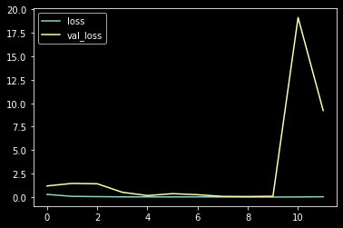

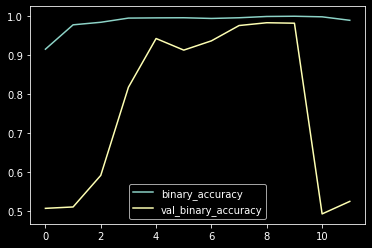

```python
train_model(batch_normal_model)
```

# Evaluation

```python
def evaluate_model(model, test_data=test_data):
    results = model.evaluate(test_data, verbose=0)
    print("Model name: ", model.name)
    print("Test Loss: {:.5f}".format(results[0]))
    print("Test Accuracy: {:.3f}%".format(results[1]*100))
    print("-"*20)


def evaluate_model_cc(model, test_data=test_data):
    results = model.evaluate(test_data, verbose=0)
    loss = results[0]
    acc = results[1]

    print("Test Loss: {:.5f}".format(loss))
    print("Test Accuracy: {:.3f}%".format(acc*100))

    y_pred = np.squeeze((model.predict(test_data) >= 0.5).astype(np.int64))
    cm = confusion_matrix(test_data.labels, y_pred)
    clr = classification_report(test_data.labels, y_pred, target_names=["NEGATIVE","POSITIVE"])

    plt.figure(figsize=(6,6))
    sns.heatmap(cm, annot=True, fmt='g', vmin=0, cmap='Blues', cbar=False)
    plt.xticks(ticks=np.arange(2) + 0.5, labels=["NEGATIVE", "POSITIVE"])
    plt.yticks(ticks=np.arange(2) + 0.5, labels=["NEGATIVE", "POSITIVE"])
    plt.xlabel("Predicted")
    plt.ylabel("Actual")
    plt.title("Confusion Matrix")
    plt.show()

    print("Classification Report:\n")
    print("-"*60)
    print(clr)
```

# Comparison of models

The batch_normal_model performed with 98.333% accuracy.

```
Test Loss: 0.06150
Test Accuracy: 98.333%
```

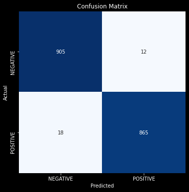

```
Classification Report:

------------------------------------------------------------
              precision    recall  f1-score   support

    NEGATIVE       0.98      0.99      0.98       917
    POSITIVE       0.99      0.98      0.98       883

    accuracy                           0.98      1800
   macro avg       0.98      0.98      0.98      1800
weighted avg       0.98      0.98      0.98      1800
```

```python
evaluate_model_cc(batch_normal_model)
```

```
Test Loss: 0.13886
Test Accuracy: 96.667%
```

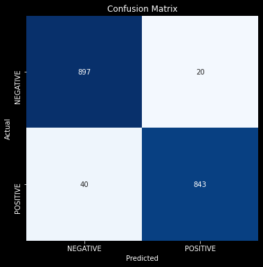

```
Classification Report:

------------------------------------------------------------
              precision    recall  f1-score   support

    NEGATIVE       0.96      0.98      0.97       917
    POSITIVE       0.98      0.95      0.97       883

    accuracy                           0.97      1800
   macro avg       0.97      0.97      0.97      1800
weighted avg       0.97      0.97      0.97      1800
```

```python
evaluate_model_cc(global_avg_model)
```

```
Test Loss: 0.09233
Test Accuracy: 97.056%
```

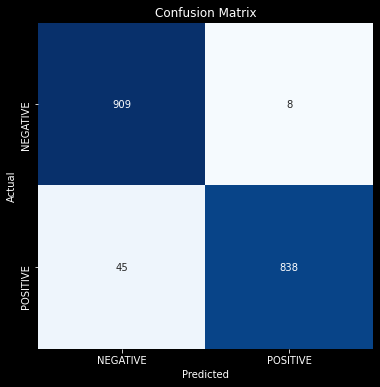

```
Classification Report:

------------------------------------------------------------
              precision    recall  f1-score   support

    NEGATIVE       0.95      0.99      0.97       917
    POSITIVE       0.99      0.95      0.97       883

    accuracy                           0.97      1800
   macro avg       0.97      0.97      0.97      1800
weighted avg       0.97      0.97      0.97      1800
```

```python
evaluate_model_cc(basic_model)
```

# Testing

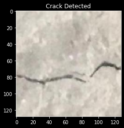

```python
image = tf.keras.preprocessing.image.load_img("C:/Users/Asus/Downloads/Concrete Crack Images for Classification/Positive/00040.jpg", target_size=(128,128))
input_arr = np.array([tf.keras.preprocessing.image.img_to_array(image)]).astype('float32') / 255
predictions = batch_normal_model.predict(input_arr)

plt.figure()
plt.imshow(image)

if(predictions[0]>=0.5):
    plt.title("Crack Detected")
else:
    plt.title("No Crack Detected")
```

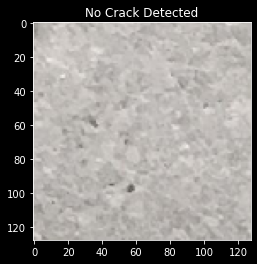

```python
image = tf.keras.preprocessing.image.load_img("C:/Users/Asus/Downloads/Concrete Crack Images for Classification/Negative/00003.jpg", target_size=(128,128))
input_arr = np.array([tf.keras.preprocessing.image.img_to_array(image)]).astype('float32') / 255
predictions = batch_normal_model.predict(input_arr)

plt.figure()
plt.imshow(image)

if(predictions[0]>=0.5):
    plt.title("Crack Detected")
else:
    plt.title("No Crack Detected")
```